# Final CMSC320 Project

### Welcome to our tutorial

Written by Sam Jalowicz and Nick Kibbey

# Part 0: Purpose

### What is this project?

This tutorial is written to walk you through the typical data science pipeline.

### Who is this written for?

You! Or anybody interested in data science. This tutorial is written for a beginner level.

### Requirements

Novice coding experience helps and we assume you have been able to use R and have an editor you are comfortable with. This project is written in R 3.6.0, RMarkdown using RStudio 1.1.463.

We will be making use of tidyverse among other packages and if you do not yet know what tidyverse is I personally recommend you to get aquainted with it at https://www.rdocumentation.org/packages/tidyverse/versions/1.2.1

### What will you be doing?

# Part 1

### Setup

We are using tidyverse and when it loads there will probably be warnings and other confusing information that may pop up but there is nothing to worry about if the proceeding code works fine.

```r
library(tidyverse)
```

### Download the data

Download from https://wri-public-data.s3.amazonaws.com/ImpactHack/Refugees.zip and unzip this folder, I left mine in my downloads but if you put the “aslyum_by_country_origin2.csv” in the same folder as your R file then you won’t need the prefix that I used for the my_refugee_addr variable.

This data will include all the countries the U.S. state department cares to include in their dataset and the amount of refugees from that country by year from 2000 - 2017.

```r
# CHANGE HERE to where you downloaded your file
# my_refugee_addr <- "/Users/sjalowicz/Desktop/Refugees/aslyum_by_country_origin2.csv"
my_refugee_addr <- "Refugees/aslyum_by_country_origin2.csv"

# Variable that stores the data
refugee_tab <- read_csv(my_refugee_addr)
# Displaying a preview of the data stored in our R program
refugee_tab
```

```
## # A tibble: 193 x 21
##    yr_2007 cartodb_id name  country_or yr_2000 yr_2001 yr_2002 yr_2003
##      <dbl>      <dbl> <chr> <chr>        <dbl>   <dbl>   <dbl>   <dbl>
##  1 3609746          1 Afgh… Afghanist… 4778785 5166652 6013458 3174558
##  2  198970          2 Ango… Angola      705464  695600  736745  474278
##  3   16982          3 Alba… Albania       9620   11604   15756   14920
##  4      12          4 Ando… Andorra          3       8      13      13
##  5     318          5 Unit… United Ar…      25      49      69      45
##  6    1292          6 Arge… Argentina     2172    2112    2104    1919
##  7   19419          7 Arme… Armenia      11014   13286   18918   18129
##  8      25          8 Anti… Antigua a…       9      13      46      31
##  9      64          9 Aust… Australia        7      12      25      22
## 10     501         10 Aust… Austria         39      33      84      77
## # … with 183 more rows, and 13 more variables: yr_2004 <dbl>,
## #   yr_2005 <dbl>, yr_2006 <dbl>, yr_2008 <dbl>, yr_2009 <dbl>,
## #   yr_2010 <dbl>, yr_2011 <dbl>, yr_2012 <dbl>, yr_2013 <dbl>,
## #   yr_2014 <dbl>, yr_2015 <dbl>, yr_2016 <dbl>, yr_2017 <dbl>
```

### Data Management

##### TL;DR, We need to modify our table if we want to graph over time

#### How are we doing that?

```r
# Please forgive me because this is about to get tedious and R is a functional language
# Which means without macros the pipeline I chose is not the best but it will work
# Again I am sorry but sometimes data science makes you do mundane parsing
# You also learn that the smarter way takes longer to do so the stupid way is used more often
temp2000 <- refugee_tab %>%
  select(name, yr_2000) %>%
  mutate(num_refugees=yr_2000, year=2000)
temp2000$yr_2000 <- NULL
```

This is the code that will bind all our temp variables together into one tall data frame.

```r
refugee_df <- bind_rows(temp2017, temp2016, temp2015, temp2014, temp2013, temp2012, temp2011,
                        temp2010, temp2009, temp2008, temp2007, temp2006, temp2005, temp2004,
                        temp2003, temp2002, temp2001, temp2000)
refugee_df
```

[output not shown]

```
## # A tibble: 3,474 x 3
##    name                 num_refugees  year
##    <chr>                       <dbl> <dbl>
##  1 Afghanistan               5336564  2017
##  2 Angola                      33831  2017
##  3 Albania                     30918  2017
##  4 Andorra                        NA  2017
##  5 United Arab Emirates          325  2017
##  6 Argentina                     466  2017
##  7 Armenia                     25697  2017
##  8 Antigua and Barbuda           153  2017
##  9 Australia                      12  2017
## 10 Austria                        27  2017
## # … with 3,464 more rows
```

Now isn’t that better?

# Part 2: Exploratory data analysis

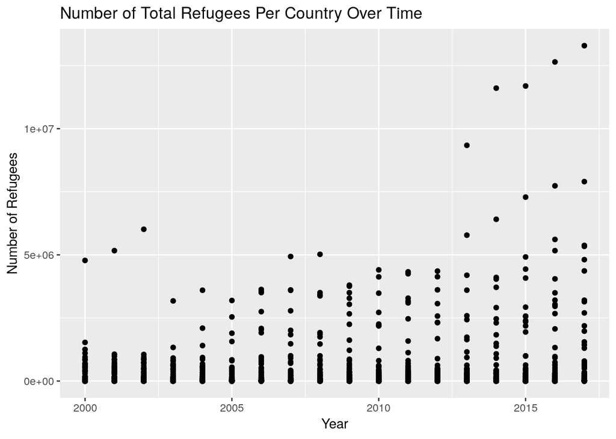

```r
library(tidyverse)
library(dplyr)

refugee_df %>%
  group_by(year) %>%
  ggplot(mapping=aes(x=year, y=num_refugees)) +
    geom_point() + labs(title="Number of Total Refugees Per Country Over Time",
          x="Year", y="Number of Refugees")
```

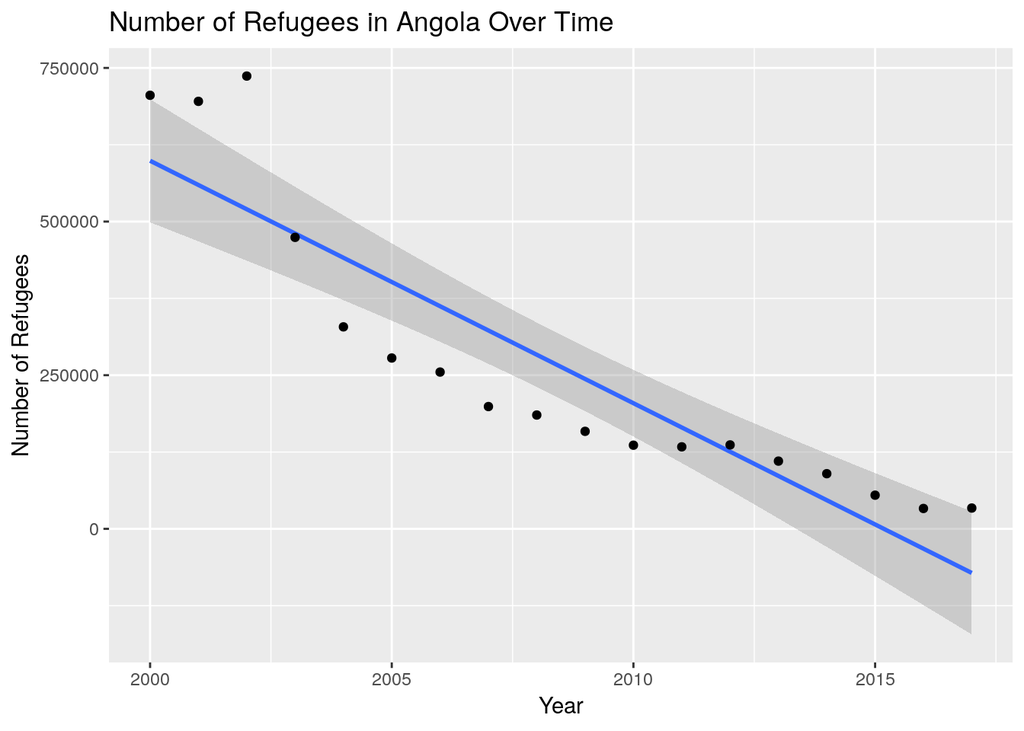

```r
refugee_df %>%
  filter(name == "Angola") %>%
  ggplot(mapping=aes(x=year, y=num_refugees)) +
    geom_smooth(method=lm) +
    geom_point() + labs(title="Number of Refugees in Angola Over Time",
          x="Year", y="Number of Refugees")
```

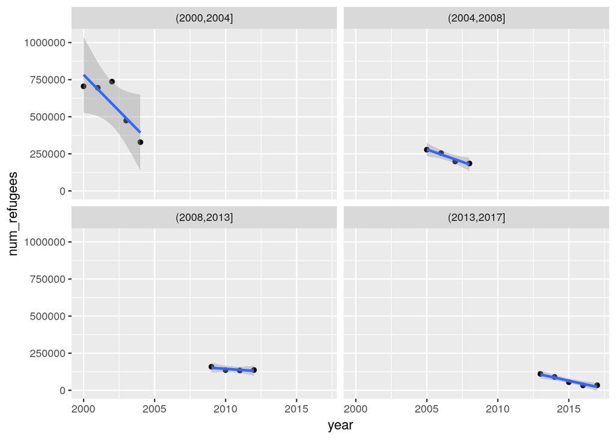

```r
library(tidyverse)
# library(nycflights13)

refugee_df %>%
  filter(name == "Angola") %>%
  mutate(cut_yearID = cut(x=year,breaks=4)) %>%
  group_by(cut_yearID, name) %>%
  rowid_to_column() %>%
  ggplot(mapping=aes(x=year, y=num_refugees)) +
    facet_wrap(~cut_yearID) +
    geom_point() +
    geom_smooth(method=lm)
```

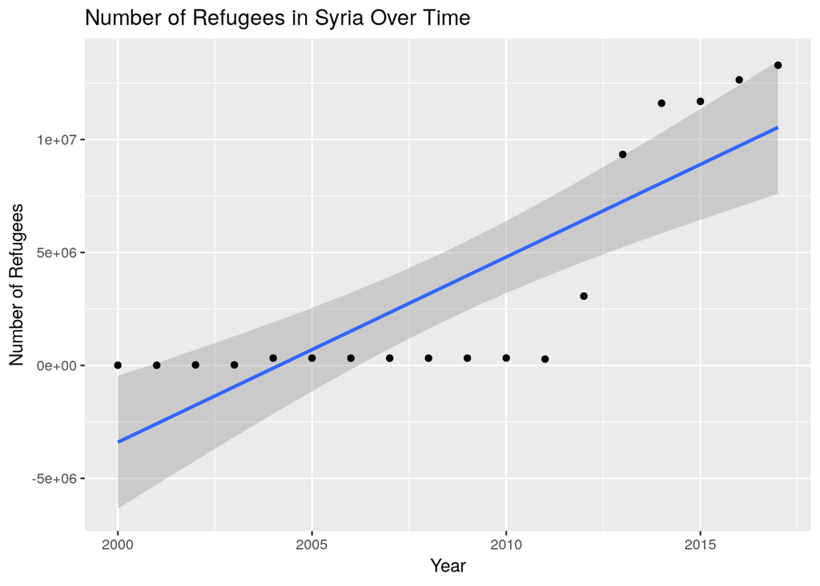

```r
refugee_df %>%
  filter(name == "Syria") %>%
  ggplot(mapping=aes(x=year, y=num_refugees)) +
    geom_smooth(method=lm) +
    geom_point() + labs(title="Number of Refugees in Syria Over Time",
          x="Year", y="Number of Refugees")
```

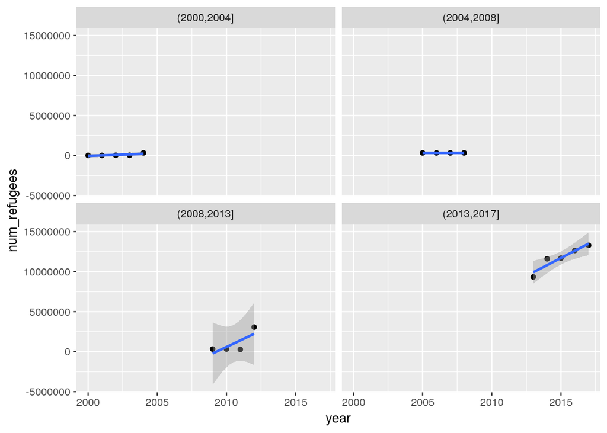

```r
library(tidyverse)
#library(nycflights13)

refugee_df %>%
  filter(name == "Syria") %>%
  mutate(cut_yearID = cut(x=year,breaks=4)) %>%
  group_by(cut_yearID, name) %>%
  rowid_to_column() %>%
  ggplot(mapping=aes(x=year, y=num_refugees)) +
    facet_wrap(~cut_yearID) +
    geom_point() +
    geom_smooth(method=lm)
```

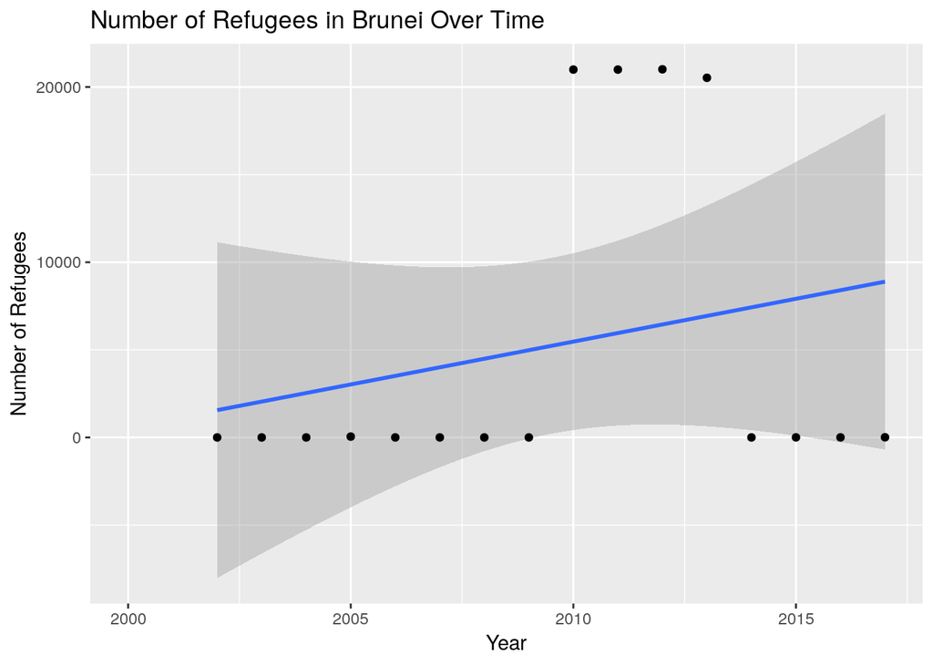

```r
refugee_df %>%
  filter(name == "Brunei") %>%
  ggplot(mapping=aes(x=year, y=num_refugees)) +
    geom_smooth(method=lm) +
    geom_point() + labs(title="Number of Refugees in Brunei Over Time",
          x="Year", y="Number of Refugees")
```

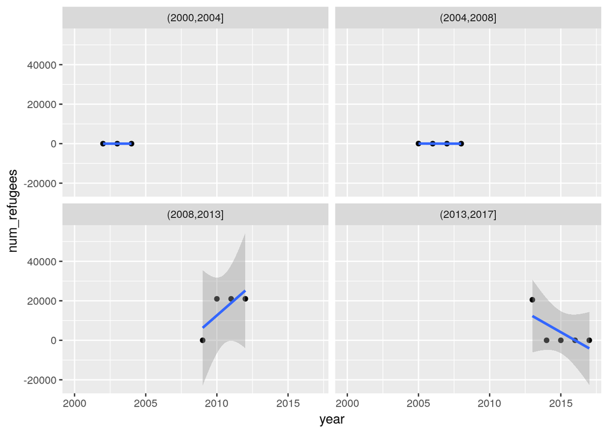

```r
library(tidyverse)
#library(nycflights13)

refugee_df %>%
  filter(name == "Brunei") %>%
  mutate(cut_yearID = cut(x=year,breaks=4)) %>%
  group_by(cut_yearID, name) %>%
  rowid_to_column() %>%
  ggplot(mapping=aes(x=year, y=num_refugees)) +
    facet_wrap(~cut_yearID) +
    geom_point() +
    geom_smooth(method=lm)
```

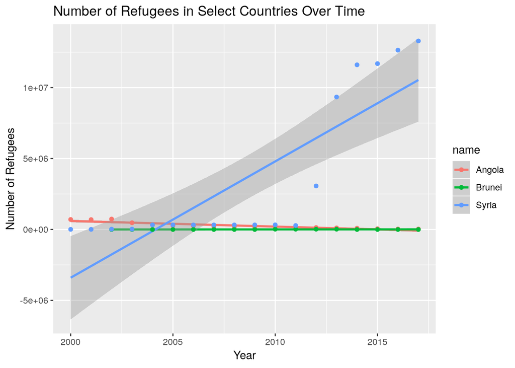

```r
refugee_df %>%
  filter(name == "Angola" | name == "Syria" | name == "Brunei") %>%
  ggplot(mapping=aes(x=year, y=num_refugees, color=name)) +
    geom_smooth(method=lm) +
    geom_point() + labs(title="Number of Refugees in Select Countries Over Time",
          x="Year", y="Number of Refugees")
```